# Stroke Prediction and Analysis

```r
null_dist %>%  get_p_value(obs_stat = observed_f_statistic, direction = "greater")
```

```
# A tibble: 1 × 1
  p_value
    <dbl>
1       0
```

We can reject H0 with extremely high confidence, indeed the p-value is approximated at 0, meaning it’s basically guaranteed that at least one group is different from the others. Now we can try to find the different group(s) and repeat the test. After seeing the means and variances of the categories, the first suspect is the children group, it’s the one with the smallest statistics and is really close only to the Never-worked category. Logically these two seem related, the latter could potentially be formed by young individuals who can’t be considered children anymore but also have never worked.

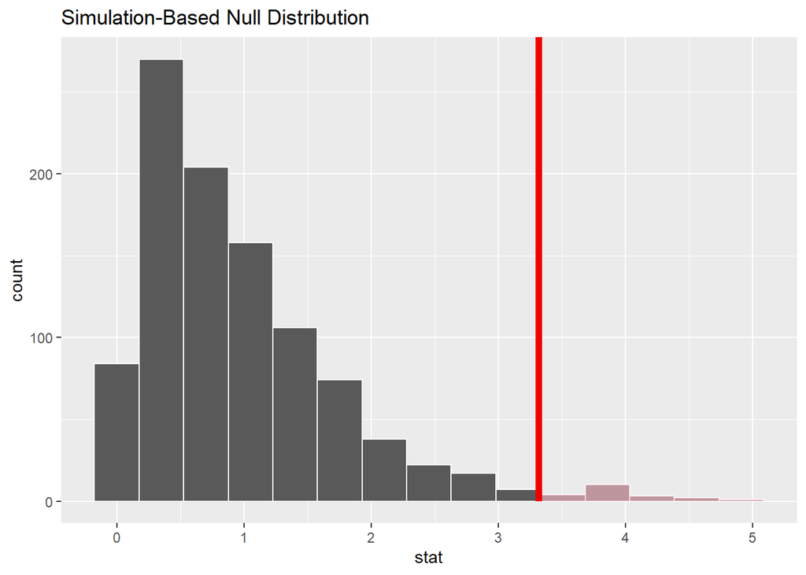

```r
data_no_children <- data %>% filter(work_type != "children")

observed_f_statistic <- data_no_children %>%  specify(bmi~work_type) %>%  hypothesize(null = "independence") %>%  calculate(stat = "F")
null_dist <- data_no_children %>%  specify(bmi~work_type) %>%  hypothesize(null = "independence") %>%  generate(reps = 1000, type = "permute") %>%  calculate(stat = "F")

null_dist %>%  visualize() +   shade_p_value(observed_f_statistic, direction = "greater")
```

```r
null_dist %>%  get_p_value(obs_stat = observed_f_statistic, direction = "greater")
```

```
# A tibble: 1 × 1
  p_value
    <dbl>
1    0.02
```

Indeed now the p-value has become bigger than before. The children category is the one significantly different from the others, it intuitively makes sense, children have often lower BMI values due to several reasons like higher metabolic rate (they burn more calories) and higher growth rate (muscles and bone density rapidly increase, possibly more than weight), and hormones effects.

However our statistics lies again in the rejection region; so we the repeat the experiment one more time, now also removing the Never_worked category.

```r
data_adults <- data %>% filter(work_type != "Never_worked" & work_type != "children")
```

```r
observed_f_statistic <- data_adults %>%  specify(bmi~work_type) %>%  hypothesize(null = "independence") %>%  calculate(stat = "F")
null_dist <- data_adults %>%  specify(bmi~work_type) %>%  hypothesize(null = "independence") %>%  generate(reps = 1000, type = "permute") %>%  calculate(stat = "F")
```

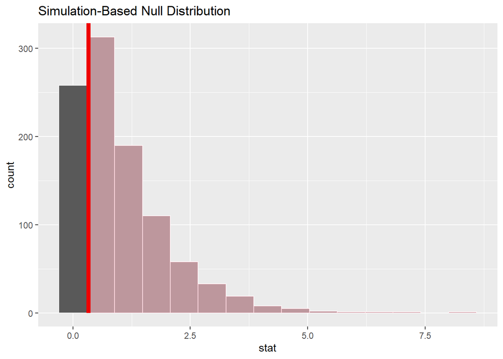

```r
null_dist %>%  visualize() +   shade_p_value(observed_f_statistic, direction = "greater")
```

```r
null_dist %>%  get_p_value(obs_stat = observed_f_statistic, direction = "greater")
```

```
# A tibble: 1 × 1
  p_value
    <dbl>
1   0.714
```

Now the p-value is very big, far away from the rejection region. The results make sense with what we noticed when we only saw the means and variances of the groups, the two groups we removed were similar between them but quite different from the others.

These results could also be interpreted as two different clusters representing young people/children and working adults.

Next we’ll do the same on the combinations between work_type and residence_type. We decided to skip the analysis based on residence_type only, as its cardinality is only 2, it can be easily handled together with the already considered group.

```r
data %>%
  group_by(work_type, Residence_type) %>%
  summarise(mean = mean(bmi), sd = sd(bmi), n = n())
```

```
# A tibble: 10 × 5
# Groups:   work_type [5]
   work_type     Residence_type  mean    sd     n
   <chr>         <chr>          <dbl> <dbl> <int>
 1 Govt_job      Rural           30.3  7.04   302
 2 Govt_job      Urban           30.7  6.81   328
 3 Never_worked  Rural           26.2  5.87     7
 4 Never_worked  Urban           25.2  8.24    15
 5 Private       Rural           30.3  7.68  1406
 6 Private       Urban           30.3  7.49  1405
 7 Self-employed Rural           30.4  6.77   371
 8 Self-employed Urban           30.1  6.62   404
 9 children      Rural           20.0  4.29   333
10 children      Urban           20.1  4.78   338
```

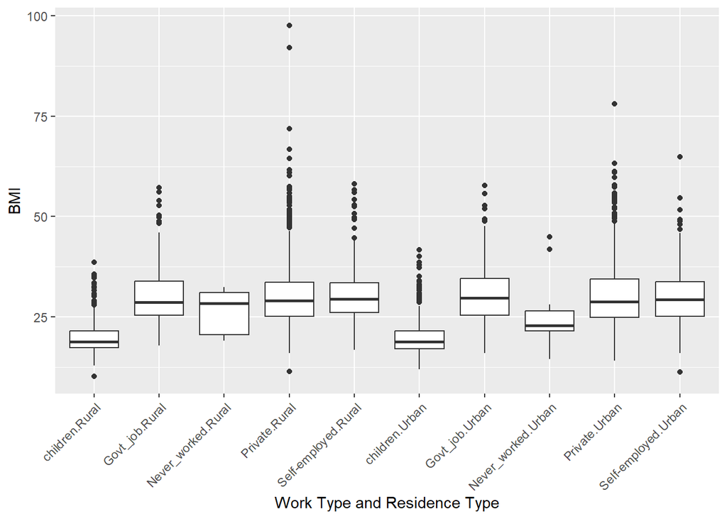

```r
data %>%
  ggplot() +
  geom_boxplot(aes(x = interaction(work_type, Residence_type), y = bmi)) +
  labs(x = "Work Type and Residence Type", y = "BMI") +
  theme(axis.text.x = element_text(angle = 45, hjust = 1))
```

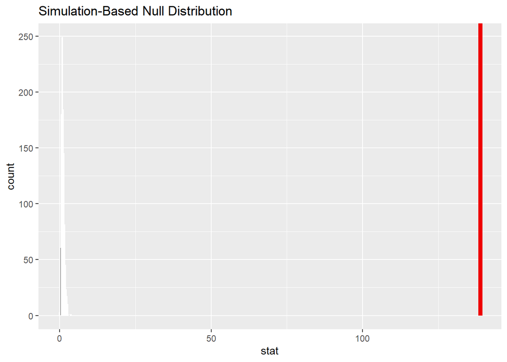

```r
data_wr_united <- data %>% unite(work_and_residence, work_type, Residence_type, sep='/')


observed_f_statistic <- data_wr_united %>%  specify(bmi~work_and_residence) %>%  hypothesize(null = "independence") %>%  calculate(stat = "F")

null_dist <- data_wr_united %>%  specify(bmi~work_and_residence) %>%  hypothesize(null = "independence") %>%  generate(reps = 1000, type = "permute") %>%  calculate(stat = "F")

null_dist %>%  visualize() +   shade_p_value(observed_f_statistic, direction = "greater")
```

We search for the groups with the most difference. From the box-plots we can identify some possible candidates, which are of course the combinations involving children and never_worked, although the distributions of the two never_worked groups seem quite different between each other. Let’s start by removing the children.

```r
data_wr_filtered <- data_wr_united %>% filter(work_and_residence != "children/Rural" & work_and_residence != "children/Urban")
```

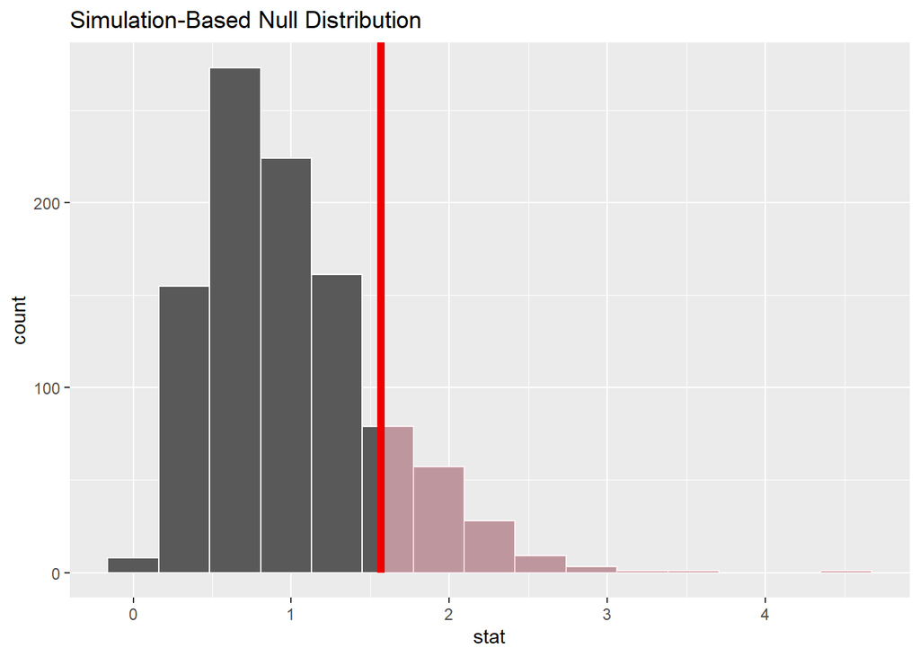

```r
observed_f_statistic <- data_wr_filtered %>%  specify(bmi~work_and_residence) %>%  hypothesize(null = "independence") %>%  calculate(stat = "F")
null_dist <- data_wr_filtered %>%  specify(bmi~work_and_residence) %>%  hypothesize(null = "independence") %>%  generate(reps = 1000, type = "permute") %>%  calculate(stat = "F")


null_dist %>%  visualize() +   shade_p_value(observed_f_statistic, direction = "greater")
```

```r
null_dist %>%  get_p_value(obs_stat = observed_f_statistic, direction = "greater")
```

```
# A tibble: 1 × 1
  p_value
    <dbl>
1   0.142
```

## Conclusions

From the analysis of the data provided by *Health&co*, it emerged that the main risk factors associated with the advent of brain strokes are advanced age, hypertension, heart disease. Smoking and BMI values are relevant for different (more extreme) probabilities. By using simple linear models such as logistic regression, we were able to predict the probability of a patient experiencing a stroke with good recall. Clearly, if we wanted better performances we could eventually experiments with other types of models, feature selection or new types of data.

Furthermore, the comparative analysis between stroke patients and those who have not experienced any, revealed significant differences in characteristics. This allows us to suggest personalized intervention strategies and increase patient awareness of behaviors and health conditions that can increase the risk of stroke. Good ideas for the future include: focusing on the identified risk factors, adopting predictive models for early risk assessment, and educating patients on healthy lifestyles. These interventions can significantly contribute to reducing the likelihood of strokes and improving the quality of life for patients.